# Collecting Job Data Using APIs (Personal Project)

This notebook is part of my personal data analytics project. Here, I collect and analyze job data using APIs for my own learning and portfolio.

# **Collecting Job Data Using APIs**

Estimated time needed: **45 to 60** minutes

## Objectives

After completing this lab, you will be able to:

- Collect job data from Jobs API
- Store the collected data into an excel spreadsheet.

> **Note: Before starting with the assignment make sure to read all the instructions and then move ahead with the coding part.**

#### Instructions

To run the actual lab, firstly you need to click on the [Jobs_API](https://cf-courses-data.s3.us.cloud-object-storage.appdomain.cloud/IBM-DA0321EN-SkillsNetwork/labs/module%201/Accessing%20Data%20Using%20APIs/Jobs_API.ipynb) notebook link. The file contains flask code which is required to run the Jobs API data.

Now, to run the code in the file that opens up follow the below steps.

Step1: Download the file.

Step2: Upload it on the IBM Watson studio. (If IBM Watson Cloud service does not work in your system, follow the alternate Step 2 below)

Step2(alternate): Upload it in your SN labs environment using the upload button which is highlighted in red in the image below: Remember to upload this Jobs_API file in the same folder as your current .ipynb file

[figure not shown]

Step3: Run all the cells of the Jobs_API file. (Even if you receive an asterik sign after running the last cell, the code works fine.)

If you want to learn more about flask, which is optional, you can click on this link [here](https://cf-courses-data.s3.us.cloud-object-storage.appdomain.cloud/IBM-DA0321EN-SkillsNetwork/labs/module%201/Accessing%20Data%20Using%20APIs/FLASK_API.md.html).

Once you run the flask code, you can start with your assignment.

## Dataset Used in this Assignment

The dataset used in this lab comes from the following source: https://www.kaggle.com/promptcloud/jobs-on-naukricom under the under a **Public Domain license**.

> Note: We are using a modified subset of that dataset for the lab, so to follow the lab instructions successfully please use the dataset provided with the lab, rather than the dataset from the original source.

The original dataset is a csv. We have converted the csv to json as per the requirement of the lab.

## Warm-Up Exercise

Before you attempt the actual lab, here is a fully solved warmup exercise that will help you to learn how to access an API.

Using an API, let us find out who currently are on the International Space Station (ISS).  
The API at http://api.open-notify.org/astros.json gives us the information of astronauts currently on ISS in json format.  
You can read more about this API at http://open-notify.org/Open-Notify-API/People-In-Space/

```python
import requests # you need this module to make an API call
import pandas as pd
```

```python
api_url = "http://api.open-notify.org/astros.json" # this url gives use the astronaut data
```

```python
response = requests.get(api_url) # Call the API using the get method and store the
                                # output of the API call in a variable called response.
```

```python
if response.ok:             # if all is well() no errors, no network timeouts)
    data = response.json()  # store the result in json format in a variable called data
                            # the variable data is of type dictionary.
```

```python
print(data)   # print the data just to check the output or for debugging
```

[output not shown]

Print the number of astronauts currently on ISS.

```python
print(data.get('number'))
```

```
10
```

Print the names of the astronauts currently on ISS.

```python
astronauts = data.get('people')
print("There are {} astronauts on ISS".format(len(astronauts)))
print("And their names are :")
for astronaut in astronauts:
    print(astronaut.get('name'))
```

```
There are 10 astronauts on ISS
And their names are :
Oleg Artemyev
Denis Matveev
Sergey Korsakov
Kjell Lindgren
Bob Hines
Samantha Cristoforetti
Jessica Watkins
Cai Xuzhe
Chen Dong
Liu Yang
```

Hope the warmup was helpful. Good luck with your next lab!

## Lab: Collect Jobs Data using Jobs API

### Objective: Determine the number of jobs currently open for various technologies and for various locations

Collect the number of job postings for the following locations using the API:

- Los Angeles
- New York
- San Francisco
- Washington DC
- Seattle
- Austin
- Detroit

```python
#Import required libraries
import pandas as pd
import json
```

#### Write a function to get the number of jobs for the Python technology.

> Note: While using the lab you need to pass the **payload** information for the **params** attribute in the form of **key** **value** pairs.

Refer the ungraded **rest api lab** in the course **Python for Data Science, AI & Development** link

##### The keys in the json are

- Job Title
- Job Experience Required
- Key Skills
- Role Category
- Location
- Functional Area
- Industry
- Role

```python
api_url="http://127.0.0.1:5000/data"
def get_number_of_jobs_T(technology):
    #your code goes here
    number_of_jobs = 0
    payload={"Key Skills":technology}
    response=requests.get(api_url,params=payload)
    if response.ok:             # if all is well() no errors, no network timeouts)
        data = response.json()  # store the result in json format in a variable called data
                                # the variable data is of type dictionary.
        number_of_jobs= number_of_jobs + len(data)
    return technology,number_of_jobs
```

Calling the function for Python and checking if it works.

```python
get_number_of_jobs_T("Python")
```

```
('Python', 1173)
```

#### Write a function to find number of jobs in US for a location of your choice

```python
def get_number_of_jobs_L(location):

    #your coe goes here
    number_of_jobs = 0
    payload={"Location":location}
    response=requests.get(api_url,params=payload)
    if response.ok:             # if all is well() no errors, no network timeouts)
        data = response.json()  # store the result in json format in a variable called data
                                # the variable data is of type dictionary.
        number_of_jobs= number_of_jobs + len(data)
    return location,number_of_jobs
```

```python
#your code goes here
get_number_of_jobs_L("Washington DC")
```

```
('Washington DC', 5316)
```

### Store the results in an excel file

Call the API for all the given technologies above and write the results in an excel spreadsheet.

Create a python list of all locations for which you need to find the number of jobs postings.

```python
#your code goes here
location = ["Los Angeles","New York","San Francisco","Washington DC","Seattle","Austin","Detroit"]
```

Import libraries required to create excel spreadsheet

```python
# your code goes here
from openpyxl import Workbook        # import Workbook class from module openpyxl
```

Create a workbook and select the active worksheet

```python
# your code goes here
wb=Workbook()                        # create a workbook object
```

Find the number of jobs postings for each of the location in the above list. Write the Location name and the number of jobs postings into the excel spreadsheet.

```python
ws=wb.active                         # use the active worksheet
ws.append(['City','Number of Jobs'])   # add a row with two columns 'City' and 'Number of Jobs'
```

```python
#your code goes here
for i in range(len(location)):
    n = get_number_of_jobs_L(location[i])
    ws.append(n)     # add a row with two columns 'location' and 'get_number_of_jobs_L(location)' value
```

```python
#your code goes here
wb.save("job-postings-location.xlsx")            # save the workbook into a file called countries.xlsx
print("Successfully Saved")
```

```
Successfully Saved
```

#### In the similar way, you can try for below given technologies and results can be stored in an excel sheet.

Collect the number of job postings for the following languages using the API:

- C
- C#
- C++
- Java
- JavaScript
- Python
- Scala
- Oracle
- SQL Server
- MySQL Server
- PostgreSQL
- MongoDB

```python
# your code goes here
wb=Workbook()                        # create a workbook object
ws=wb.active                         # use the active worksheet
technology = ["C","C#","C++","Java","JavaScript","Python","Scala","Oracle","SQL Server","MySQL Server","PostgreSQL","MongoDB"]
ws.append(['Technology','Number of Jobs'])   # add a row with two columns 'Technology' and 'Number of Jobs'
#your code goes here
for i in range(len(technology)):
    n = get_number_of_jobs_T(technology[i])
    ws.append(n)     # add a row with two columns 'technology' and 'get_number_of_jobs_L(technology)' value
wb.save("job-postings-technology.xlsx")            # save the workbook into a file called job-postings-technology.xlsx
print("Successfully Saved")
```

```
Successfully Saved
```

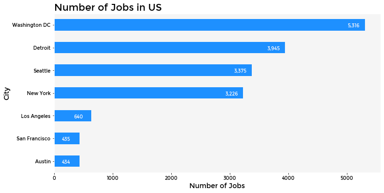

```python
import pandas as pd
import seaborn as sns
import numpy as np

# use the inline backend to generate the plots within the browser
%matplotlib inline

import matplotlib as mpl
import matplotlib.pyplot as plt

mpl.style.use('ggplot') # optional: for ggplot-like style

# check for latest version of Matplotlib
# print ('Matplotlib version: ', mpl.__version__) # >= 2.0.0

df = pd.read_excel("job-postings-location.xlsx")


df = df.set_index("City")
# df["count"]=df["count"].astype('int')
df = df.sort_values("Number of Jobs",axis = 0, ascending = True)

fig, ax = plt.subplots(figsize=(12,6))
# df.rename(columns={'count':'Total People Opinion'}, inplace=True)

df.plot(kind='barh', legend = False, ax=ax, color='dodgerblue')
ax.set_xlabel('Number of Jobs',color='black',fontfamily="Montserrat",fontsize=14)
ax.set_ylabel('City',color='black',fontfamily="Montserrat",fontsize=14)
ax.set_title('Number of Jobs in US',color='black',fontfamily="Montserrat",fontsize=20,loc='left')
ax.set_facecolor('whitesmoke')
ax.tick_params(axis='x', colors='black')    #setting up X-axis tick color to black
ax.tick_params(axis='y', colors='black')    #setting up Y-axis tick color to black
plt.rcParams["font.family"] = "Montserrat"
plt.grid(visible=None)


# annotate value labels to each country
for i in range(len(df)): #enamurate returns tuple
    # print(df["Total People Opinion"][i])
    value = df["Number of Jobs"][i]
    label = format(int(value), ',') # format int with commas

# place text at the end of bar (subtracting 700 from x, and 0.1 from y to make it fit within the bar)
    plt.annotate(label, xy=(value-300, i-0.1), color='snow')
plt.savefig("us_jobs.png")
plt.show()
```

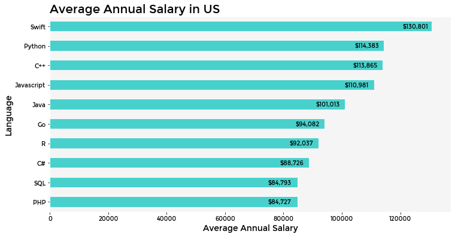

```python
import pandas as pd
import seaborn as sns
import numpy as np

# use the inline backend to generate the plots within the browser
%matplotlib inline

import matplotlib as mpl
import matplotlib.pyplot as plt

mpl.style.use('ggplot') # optional: for ggplot-like style

# check for latest version of Matplotlib
# print ('Matplotlib version: ', mpl.__version__) # >= 2.0.0

df = pd.read_csv("popular-languages.csv")


df = df.set_index("Language")
df = df.sort_values("Average Annual Salary",axis = 0, ascending = True)

# df["count"]=df["count"].astype('int')


fig, ax = plt.subplots(figsize=(12,6))

df.plot(kind='barh', legend = False, ax=ax, color='mediumturquoise')
ax.set_xlabel('Average Annual Salary',color='black',fontfamily="Montserrat",fontsize=14)
ax.set_ylabel('Language',color='black',fontfamily="Montserrat",fontsize=14)
ax.set_title('Average Annual Salary in US',color='black',fontfamily="Montserrat",fontsize=20,loc='left')
ax.set_facecolor('whitesmoke')

ax.tick_params(axis='x', colors='black')    #setting up X-axis tick color to black
ax.tick_params(axis='y', colors='black')    #setting up Y-axis tick color to black

plt.rcParams["font.family"] = "Montserrat"
plt.grid(visible=None)


# annotate value labels to each country
for i in range(len(df)): #enamurate returns tuple
    # print(df["Total People Opinion"][i])
    value = df["Average Annual Salary"][i]
    label = format(int(value), ',') # format int with commas

# place text at the end of bar (subtracting 700 from x, and 0.1 from y to make it fit within the bar)
    plt.annotate("$"+label, xy=(value-10000, i-0.1), color='black')
plt.savefig("annual_salary.png")
plt.show()
```

Copyright © 2022 IBM Corporation. All rights reserved.